### Homework Guidelines:

Please read Homework Guidelines. You must follow these guidelines.

### Turning the Homework in:

*Please turn the homework in through canvas. You may use a pdf, html or word doc file to turn the assignment in.*

[PHP 1511 Assignment Link](https://canvas.brown.edu/courses/1075279/assignments/7690890)

[PHP 2511 Assignment Link](https://canvas.brown.edu/courses/1075280/assignments/7690891)

*For the R Markdown Version of this assignment: HW4.Rmd*

## Part 1: Both PHP 1511 and 2511

We will be considering the Titanic Dataset. The variables in this dataset are:

| variable | Description |
| --- | --- |
| survival | Survival 0 = No, 1 = Yes |
| pclass | Ticket class 1 = 1st, 2 = 2nd, 3 = 3rd |
| sex | Sex |
| Age | Age in years |
| sibsp | # of siblings / spouses aboard the Titanic |
| parch | # of parents / children aboard the Titanic |
| ticket | Ticket number |
| fare | Passenger fare |
| cabin | Cabin number |
| embarked | Port of Embarkation C = Cherbourg, Q = Queenstown, S = Southampton |

Your goal will be to consider a logistic regression to model Survival. The thought behind survival was that it was about women and children first. Your goal will be to model this relationship and to understand what else might have played a role in survival.

1. Display through tables or plots:
   1. Survival by age
   2. Survival by sex
   3. Survival by embarked
   4. Survival by pclass Then comment on what you notice about these relationships.

```
##       age              sex      embarked     pclass
##  Min.   : 0.1667         :  1    :  3    Min.   :1.000
##  1st Qu.:21.0000   female:466   C:270    1st Qu.:2.000
##  Median :28.0000   male  :843   Q:123    Median :3.000
##  Mean   :29.8811                S:914    Mean   :2.295
##  3rd Qu.:39.0000                         3rd Qu.:3.000
##  Max.   :80.0000                         Max.   :3.000
##  NA's   :264                             NA's   :1
```

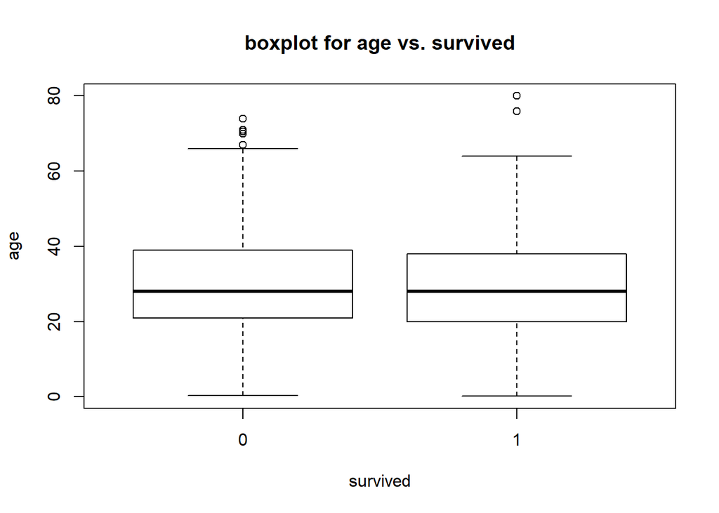

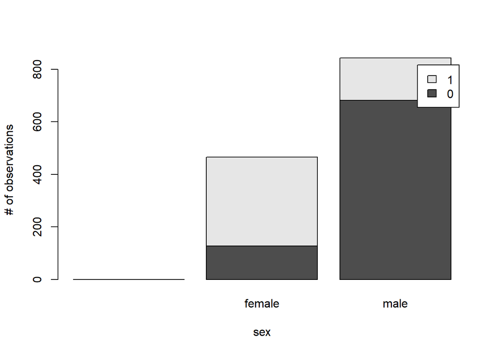

```
##         sex
## survived     female male
##        0   0    127  682
##        1   0    339  161
```

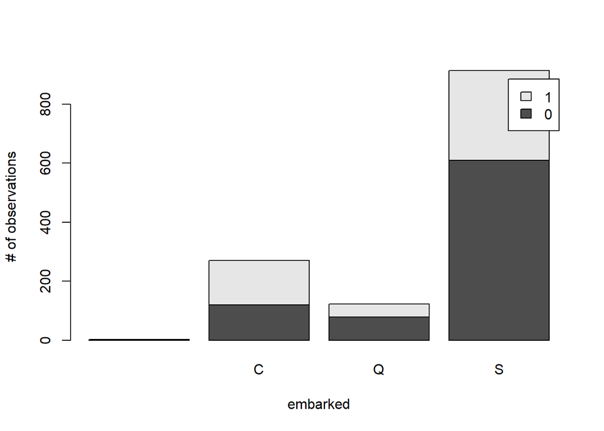

```
##         embarked
## survived       C   Q   S
##        0   0 120  79 610
##        1   2 150  44 304
```

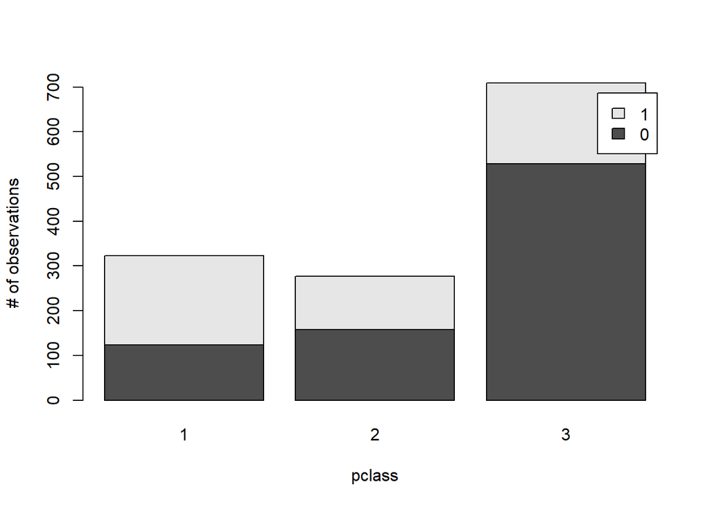

```
##         pclass
## survived   1   2   3
##        0 123 158 528
##        1 200 119 181
```

2. Build a logistic regression model with main effects only. Start with a table of univariate models and display a final multiple variable model. Include:
   - A few sentences on what you notice in simple regressions.
   - A sentence or two about why you chose your multiple model.
   - Does your model suggest that survival was about women and children?

| term | estimate | p.value | conf.low | conf.high |
| --- | --- | --- | --- | --- |
| age | 0.9916223 | 0.0572053 | 0.9830083 | 1.0002200 |
| sexmale | 0.0889642 | 0.0000000 | 0.0679174 | 0.1158117 |
| pclass2 | 0.4678750 | 0.0000055 | 0.3366091 | 0.6482062 |
| pclass3 | 0.2129534 | 0.0000000 | 0.1603756 | 0.2815815 |
| sibsp | 0.9465592 | 0.3315825 | 0.8441525 | 1.0549177 |
| parch | 1.2158079 | 0.0032117 | 1.0693717 | 1.3880314 |
| fare | 1.0124067 | 0.0000000 | 1.0093661 | 1.0157170 |
| embarkedQ | 0.4455696 | 0.0003165 | 0.2853798 | 0.6889279 |
| embarkedS | 0.3986885 | 0.0000000 | 0.3019403 | 0.5253147 |

**In simple regression:**

$sibsp$ and $age$ is not significant at 0.05 level. The other variables are all significant at the 0.05 level. People with more parents and children tend to have higher odds of survival comparing to people with less parents and children. Also, people pay higher fare tend to have higher odds of survival. People embarked at Queenstown and Southampton have lower odds of survival comparing to people embarked at cherbourg. Male has lower odds to survive than female. People in 2 and 3 pclass have lower odds to survive comparing to people in 1 pclass.

**Multiple regression:** We include variables that are significant at 0.05 level in the univariate regression. Although $age$ is not significant at 0.05 level in the univariate model, it is significant at 0.1 level. Thus, we include $age$ as well to see if it become more significant in the multiple regression.

```
##          term    estimate      p.value    conf.low   conf.high
## 1 (Intercept) 54.64528748 4.648531e-22 24.64188378 125.2947712
## 2         age  0.96684800 2.011278e-07  0.95446467   0.9790700
## 3     sexmale  0.07738908 2.513670e-48  0.05453249   0.1084373
## 4     pclass2  0.34999325 7.461558e-05  0.20746844   0.5871387
## 5     pclass3  0.13140270 1.370301e-13  0.07634670   0.2241205
## 6       parch  0.95526451 6.459864e-01  0.78261528   1.1583244
## 7        fare  0.99958246 8.255563e-01  0.99594179   1.0034682
## 8   embarkedQ  0.24604140 1.325880e-03  0.10225282   0.5700993
## 9   embarkedS  0.48589937 7.293564e-04  0.31930304   0.7384509
```

After the first fitting, $parch$ and $fare$ become insignificant in the multiple regression model. We delete these two variables and fit the model for the second time. And we compare the second model with the first model using likelihood ratio test.

```
## Analysis of Deviance Table
##
## Model 1: survived ~ age + sex + pclass + embarked
## Model 2: survived ~ age + sex + pclass + parch + fare + embarked
##   Resid. Df Resid. Dev Df Deviance Pr(>Chi)
## 1      1036     966.23
## 2      1034     965.89  2  0.34225   0.8427
```

The result of the LRT shows that the first model is not better than the second model. So, our final multiple model would be the second model:

```
##          term    estimate      p.value    conf.low   conf.high
## 1 (Intercept) 49.74740058 2.103761e-28 25.31133764 101.3219893
## 2         age  0.96732613 2.289335e-07  0.95506448   0.9794345
## 3     sexmale  0.07925099 2.267002e-50  0.05645628   0.1099410
## 4     pclass2  0.36136449 2.015015e-05  0.22527319   0.5749360
## 5     pclass3  0.13568328 2.596013e-17  0.08479387   0.2140976
## 6   embarkedQ  0.25322014 1.497348e-03  0.10616219   0.5822981
## 7   embarkedS  0.48897316 7.059966e-04  0.32281312   0.7394688
```

**survival was about women and children?** From our final model we can tell that:

On average, male have an odds of survival 0.079 times that of female. And the 95%CI also indicates this result is significant at 0.05 level. Thus, male have much less likely to survive comparing to female. Survival was about women.

On average, one unit increase in age results in an odds of survival decrease by 0.03 times. And the 95%CI also indicates this result is significant at 0.05 level. The older the less likely for a people to survive. Thus, Survival was about age.

To see more clearly if survival was about children. We divide people into age groups(<18:children, >=18:adult) and fit another model:

```
##                term    estimate      p.value   conf.low  conf.high
## 1       (Intercept) 12.71681229 7.932989e-28 8.14663155 20.2853310
## 2 age.groupchildren  2.44758213 8.355844e-05 1.56884564  3.8320307
## 3           sexmale  0.07887349 2.440969e-51 0.05634033  0.1091330
## 4           pclass2  0.49048074 1.422493e-03 0.31576519  0.7584442
## 5           pclass3  0.19779801 1.297760e-14 0.13031941  0.2974367
## 6         embarkedQ  0.24815141 1.133135e-03 0.10482014  0.5649677
## 7         embarkedS  0.48296083 5.332403e-04 0.31950292  0.7287607
```

The result shows that children have an odds of survival 2.45 times that of adults. And the 95%CI also indicates this result is significant at 0.05 level. Thus, children are much more likely to survive comparing to adults. Survival was about children.

3. Is this model well calibrate? Explain and display results or a figure to back your explanations.

```
##
##  Hosmer and Lemeshow goodness of fit (GOF) test
##
## data:  titanic$survived, fitted(m1)
## X-squared = 31.633, df = 8, p-value = 0.0001083
```

The test result shows that the result is not well calibrate.

4. Does this model discriminate well? Explain and display results or a figure to back your explanations.

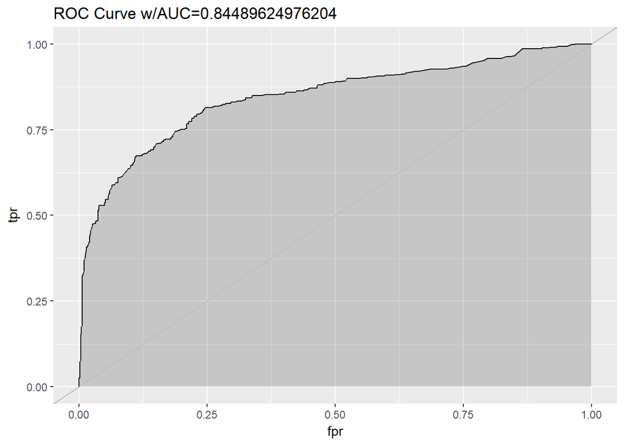

From the plot above, we can tell that $AUC = 0.84$, which means that the model discriminates well.

## Part 2: 2511 Only

5. Build a Logistic regression model exploring the interaction between sex and class by including the interaction into your multiple regression model above. Include:
   - a sentence or two on how this changes your above results.
   - a sentence or two on what this tells you about sex and class.
   - interpret the survival for females and then interpret the survival for males.

```
##              term     estimate      p.value     conf.low    conf.high
## 1     (Intercept) 173.90437635 5.783300e-20 62.401936284 585.47208241
## 2             age   0.96372798 5.781366e-08  0.950761636   0.97651058
## 3         sexmale   0.02073195 5.147045e-15  0.006915017   0.05003999
## 4         pclass2   0.29560125 3.294744e-02  0.088284543   0.86790177
## 5         pclass3   0.02352702 3.599678e-13  0.007593818   0.05938926
## 6       embarkedQ   0.32392417 8.246970e-03  0.136053228   0.73049695
## 7       embarkedS   0.47032275 4.603741e-04  0.308354998   0.71805421
## 8 sexmale:pclass2   0.89778144 8.649224e-01  0.267619699   3.33241085
## 9 sexmale:pclass3  11.55225891 6.914962e-06  4.276654011  37.37774237
```

6. How is the calibration and discrimination of this model?

```
##
##  Hosmer and Lemeshow goodness of fit (GOF) test
##
## data:  titanic$survived, fitted(m3)
## X-squared = 11.625, df = 8, p-value = 0.1688
```

The model is well calibrated.

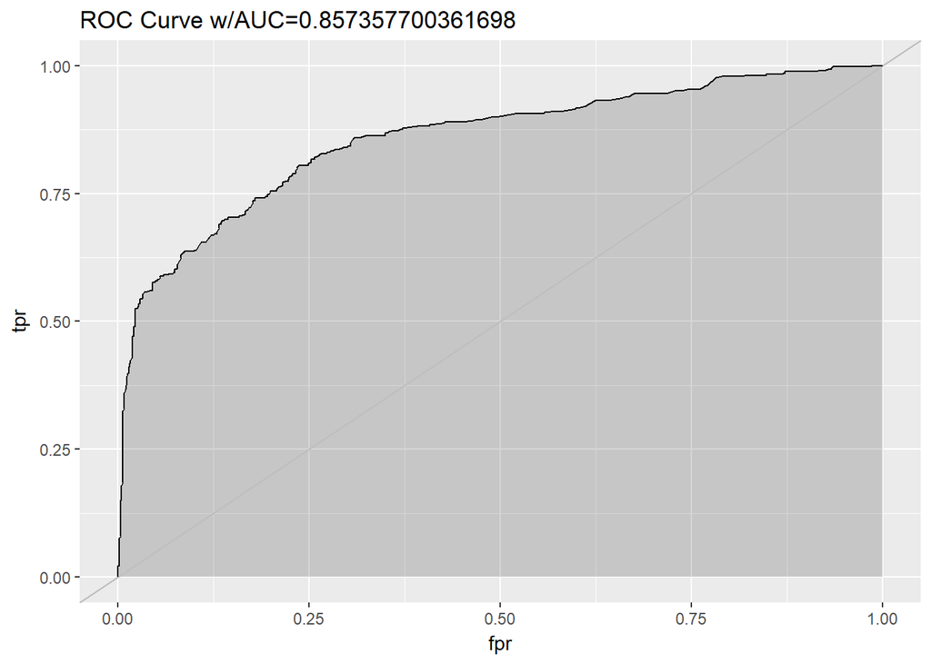